# Risk Factor Analysis

## Outcome Variable

**Outcome Variable:** swasted

## Predictor Variables

**Intervention Variable:** parity

**Adjustment Set:**

unadjusted

## Stratifying Variables

The analysis was stratified on these variable(s):

- agecat
- studyid
- country

## Data Summary

| agecat | studyid | country | parity | swasted | n_cell | n | outcome_variable |
| --- | --- | --- | --- | --- | --- | --- | --- |
| Birth | ki1000304b-SAS-CompFeed | INDIA | 1 | 0 | 289 | 1103 | swasted |
| Birth | ki1000304b-SAS-CompFeed | INDIA | 1 | 1 | 15 | 1103 | swasted |
| Birth | ki1000304b-SAS-CompFeed | INDIA | 2 | 0 | 253 | 1103 | swasted |
| Birth | ki1000304b-SAS-CompFeed | INDIA | 2 | 1 | 5 | 1103 | swasted |
| Birth | ki1000304b-SAS-CompFeed | INDIA | 3+ | 0 | 532 | 1103 | swasted |
| Birth | ki1000304b-SAS-CompFeed | INDIA | 3+ | 1 | 9 | 1103 | swasted |
| Birth | ki1017093b-PROVIDE | BANGLADESH | 1 | 0 | 194 | 532 | swasted |
| Birth | ki1017093b-PROVIDE | BANGLADESH | 1 | 1 | 8 | 532 | swasted |
| Birth | ki1017093b-PROVIDE | BANGLADESH | 2 | 0 | 180 | 532 | swasted |
| Birth | ki1017093b-PROVIDE | BANGLADESH | 2 | 1 | 2 | 532 | swasted |
| Birth | ki1017093b-PROVIDE | BANGLADESH | 3+ | 0 | 145 | 532 | swasted |
| Birth | ki1017093b-PROVIDE | BANGLADESH | 3+ | 1 | 3 | 532 | swasted |
| Birth | ki1101329-Keneba | GAMBIA | 1 | 0 | 131 | 1338 | swasted |
| Birth | ki1101329-Keneba | GAMBIA | 1 | 1 | 15 | 1338 | swasted |
| Birth | ki1101329-Keneba | GAMBIA | 2 | 0 | 133 | 1338 | swasted |
| Birth | ki1101329-Keneba | GAMBIA | 2 | 1 | 9 | 1338 | swasted |
| Birth | ki1101329-Keneba | GAMBIA | 3+ | 0 | 978 | 1338 | swasted |
| Birth | ki1101329-Keneba | GAMBIA | 3+ | 1 | 72 | 1338 | swasted |
| Birth | ki1113344-GMS-Nepal | NEPAL | 1 | 0 | 174 | 641 | swasted |
| Birth | ki1113344-GMS-Nepal | NEPAL | 1 | 1 | 11 | 641 | swasted |
| Birth | ki1113344-GMS-Nepal | NEPAL | 2 | 0 | 160 | 641 | swasted |
| Birth | ki1113344-GMS-Nepal | NEPAL | 2 | 1 | 9 | 641 | swasted |
| Birth | ki1113344-GMS-Nepal | NEPAL | 3+ | 0 | 280 | 641 | swasted |
| Birth | ki1113344-GMS-Nepal | NEPAL | 3+ | 1 | 7 | 641 | swasted |
| Birth | ki1126311-ZVITAMBO | ZIMBABWE | 1 | 0 | 5154 | 12916 | swasted |
| Birth | ki1126311-ZVITAMBO | ZIMBABWE | 1 | 1 | 407 | 12916 | swasted |
| Birth | ki1126311-ZVITAMBO | ZIMBABWE | 2 | 0 | 3671 | 12916 | swasted |
| Birth | ki1126311-ZVITAMBO | ZIMBABWE | 2 | 1 | 211 | 12916 | swasted |
| Birth | ki1126311-ZVITAMBO | ZIMBABWE | 3+ | 0 | 3299 | 12916 | swasted |
| Birth | ki1126311-ZVITAMBO | ZIMBABWE | 3+ | 1 | 174 | 12916 | swasted |

[output cut: 144 more lines]

The following strata were considered:

- agecat: 24 months, studyid: ki1017093b-PROVIDE, country: BANGLADESH
- agecat: 24 months, studyid: ki1066203-TanzaniaChild2, country: TANZANIA, UNITED REPUBLIC OF
- agecat: 24 months, studyid: ki1101329-Keneba, country: GAMBIA
- agecat: 24 months, studyid: ki1113344-GMS-Nepal, country: NEPAL
- agecat: 24 months, studyid: ki1126311-ZVITAMBO, country: ZIMBABWE
- agecat: 24 months, studyid: ki1135781-COHORTS, country: GUATEMALA
- agecat: 24 months, studyid: ki1135781-COHORTS, country: INDIA
- agecat: 24 months, studyid: ki1135781-COHORTS, country: PHILIPPINES
- agecat: 24 months, studyid: kiGH5241-JiVitA-3, country: BANGLADESH
- agecat: 6 months, studyid: ki1000304b-SAS-CompFeed, country: INDIA
- agecat: 6 months, studyid: ki1000304b-SAS-FoodSuppl, country: INDIA
- agecat: 6 months, studyid: ki1017093b-PROVIDE, country: BANGLADESH
- agecat: 6 months, studyid: ki1066203-TanzaniaChild2, country: TANZANIA, UNITED REPUBLIC OF
- agecat: 6 months, studyid: ki1101329-Keneba, country: GAMBIA
- agecat: 6 months, studyid: ki1113344-GMS-Nepal, country: NEPAL
- agecat: 6 months, studyid: ki1126311-ZVITAMBO, country: ZIMBABWE
- agecat: 6 months, studyid: ki1135781-COHORTS, country: GUATEMALA
- agecat: 6 months, studyid: ki1135781-COHORTS, country: INDIA
- agecat: 6 months, studyid: ki1135781-COHORTS, country: PHILIPPINES
- agecat: 6 months, studyid: kiGH5241-JiVitA-3, country: BANGLADESH
- agecat: Birth, studyid: ki1000304b-SAS-CompFeed, country: INDIA
- agecat: Birth, studyid: ki1017093b-PROVIDE, country: BANGLADESH
- agecat: Birth, studyid: ki1101329-Keneba, country: GAMBIA
- agecat: Birth, studyid: ki1113344-GMS-Nepal, country: NEPAL
- agecat: Birth, studyid: ki1126311-ZVITAMBO, country: ZIMBABWE
- agecat: Birth, studyid: ki1135781-COHORTS, country: GUATEMALA
- agecat: Birth, studyid: ki1135781-COHORTS, country: INDIA
- agecat: Birth, studyid: ki1135781-COHORTS, country: PHILIPPINES
- agecat: Birth, studyid: kiGH5241-JiVitA-3, country: BANGLADESH

### Dropped Strata

Some strata were dropped due to rare outcomes:

- agecat: Birth, studyid: ki1017093b-PROVIDE, country: BANGLADESH
- agecat: 6 months, studyid: ki1000304b-SAS-FoodSuppl, country: INDIA
- agecat: 6 months, studyid: ki1017093b-PROVIDE, country: BANGLADESH
- agecat: 6 months, studyid: ki1066203-TanzaniaChild2, country: TANZANIA, UNITED REPUBLIC OF
- agecat: 6 months, studyid: ki1101329-Keneba, country: GAMBIA
- agecat: 6 months, studyid: ki1113344-GMS-Nepal, country: NEPAL
- agecat: 6 months, studyid: ki1135781-COHORTS, country: GUATEMALA
- agecat: 6 months, studyid: ki1135781-COHORTS, country: PHILIPPINES
- agecat: 24 months, studyid: ki1017093b-PROVIDE, country: BANGLADESH
- agecat: 24 months, studyid: ki1066203-TanzaniaChild2, country: TANZANIA, UNITED REPUBLIC OF
- agecat: 24 months, studyid: ki1101329-Keneba, country: GAMBIA
- agecat: 24 months, studyid: ki1113344-GMS-Nepal, country: NEPAL
- agecat: 24 months, studyid: ki1135781-COHORTS, country: GUATEMALA
- agecat: 24 months, studyid: ki1135781-COHORTS, country: INDIA
- agecat: 24 months, studyid: ki1135781-COHORTS, country: PHILIPPINES

## Methods Detail

We’re interested in the causal parameters $E[Y_a]$ for all values of $a \in \mathcal{A}$. These parameters represent the mean outcome if, possibly contrary to fact, we intervened to set all units to have $A=a$. Under the randomization and positivity assumptions, these are identified by the statistical parameters $\psi_a=E_W[E_{Y|A,W}(Y|A=a,W)]$. In addition, we’re interested in the mean of $Y$, $E[Y]$ under no intervention (the observed mean). We will estimate these parameters by using SuperLearner to fit the relevant likelihood factors – $E_{Y|A,W}(Y|A=a,W)$ and $p(A=a|W)$, and then updating our likelihood fit using a joint TMLE.

For unadjusted analyses ($W=\{\}$), initial likelihoods were estimated using Lrnr_glm to estimate the simple $E(Y|A)$ and Lrnr_mean to estimate $p(A)$. For adjusted analyses, a small library containing Lrnr_glmnet, Lrnr_xgboost, and Lrnr_mean was used.

Having estimated these parameters, we will then use the delta method to estimate relative risks and attributable risks relative to a prespecified baseline level of $A$.

# Results Detail

## Results Plots

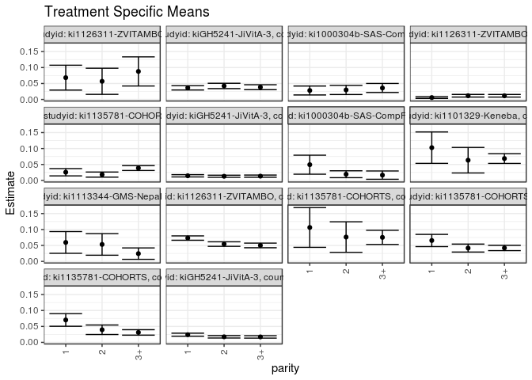

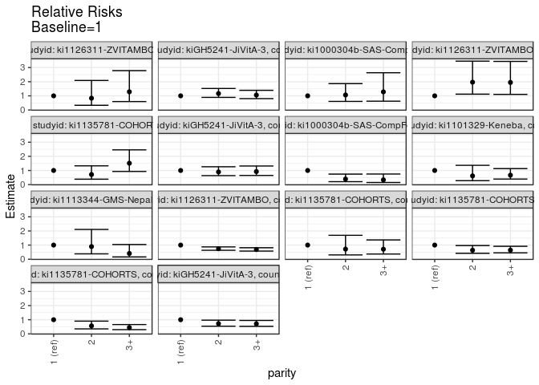

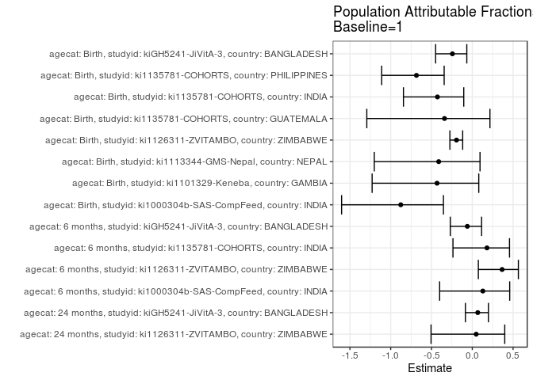

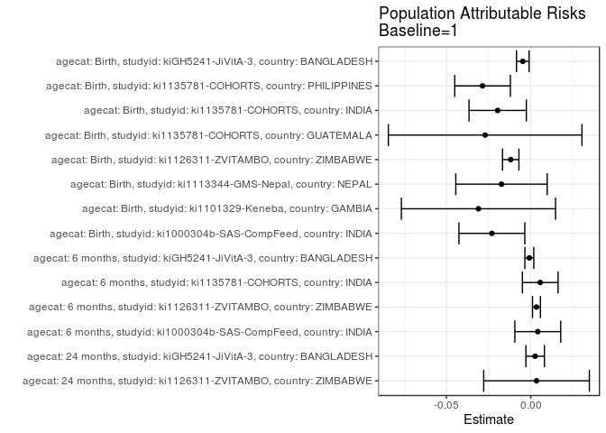

## Results Table

### Parameter: TSM

| agecat | studyid | country | intervention_level | baseline_level | estimate | ci_lower | ci_upper |
| --- | --- | --- | --- | --- | --- | --- | --- |
| Birth | ki1000304b-SAS-CompFeed | INDIA | 1 | NA | 0.0493421 | 0.0195565 | 0.0791278 |
| Birth | ki1000304b-SAS-CompFeed | INDIA | 2 | NA | 0.0193798 | 0.0085871 | 0.0301725 |
| Birth | ki1000304b-SAS-CompFeed | INDIA | 3+ | NA | 0.0166359 | 0.0036649 | 0.0296069 |
| Birth | ki1101329-Keneba | GAMBIA | 1 | NA | 0.1027397 | 0.0534720 | 0.1520074 |
| Birth | ki1101329-Keneba | GAMBIA | 2 | NA | 0.0633803 | 0.0232913 | 0.1034693 |
| Birth | ki1101329-Keneba | GAMBIA | 3+ | NA | 0.0685714 | 0.0532795 | 0.0838634 |
| Birth | ki1113344-GMS-Nepal | NEPAL | 1 | NA | 0.0594595 | 0.0253558 | 0.0935631 |
| Birth | ki1113344-GMS-Nepal | NEPAL | 2 | NA | 0.0532544 | 0.0193748 | 0.0871340 |
| Birth | ki1113344-GMS-Nepal | NEPAL | 3+ | NA | 0.0243902 | 0.0065298 | 0.0422507 |
| Birth | ki1126311-ZVITAMBO | ZIMBABWE | 1 | NA | 0.0731883 | 0.0663428 | 0.0800338 |
| Birth | ki1126311-ZVITAMBO | ZIMBABWE | 2 | NA | 0.0543534 | 0.0472214 | 0.0614855 |
| Birth | ki1126311-ZVITAMBO | ZIMBABWE | 3+ | NA | 0.0501008 | 0.0428452 | 0.0573564 |
| Birth | ki1135781-COHORTS | GUATEMALA | 1 | NA | 0.1063830 | 0.0440119 | 0.1687541 |
| Birth | ki1135781-COHORTS | GUATEMALA | 2 | NA | 0.0762712 | 0.0283479 | 0.1241945 |
| Birth | ki1135781-COHORTS | GUATEMALA | 3+ | NA | 0.0753676 | 0.0531697 | 0.0975656 |
| Birth | ki1135781-COHORTS | INDIA | 1 | NA | 0.0655226 | 0.0463644 | 0.0846809 |
| Birth | ki1135781-COHORTS | INDIA | 2 | NA | 0.0417515 | 0.0292396 | 0.0542634 |
| Birth | ki1135781-COHORTS | INDIA | 3+ | NA | 0.0421147 | 0.0337811 | 0.0504483 |
| Birth | ki1135781-COHORTS | PHILIPPINES | 1 | NA | 0.0703125 | 0.0505010 | 0.0901240 |
| Birth | ki1135781-COHORTS | PHILIPPINES | 2 | NA | 0.0395738 | 0.0246639 | 0.0544838 |
| Birth | ki1135781-COHORTS | PHILIPPINES | 3+ | NA | 0.0312110 | 0.0226945 | 0.0397275 |
| Birth | kiGH5241-JiVitA-3 | BANGLADESH | 1 | NA | 0.0240942 | 0.0193638 | 0.0288246 |
| Birth | kiGH5241-JiVitA-3 | BANGLADESH | 2 | NA | 0.0174520 | 0.0137105 | 0.0211935 |
| Birth | kiGH5241-JiVitA-3 | BANGLADESH | 3+ | NA | 0.0171216 | 0.0133069 | 0.0209364 |
| 6 months | ki1000304b-SAS-CompFeed | INDIA | 1 | NA | 0.0280612 | 0.0140579 | 0.0420646 |
| 6 months | ki1000304b-SAS-CompFeed | INDIA | 2 | NA | 0.0298013 | 0.0154373 | 0.0441654 |
| 6 months | ki1000304b-SAS-CompFeed | INDIA | 3+ | NA | 0.0359375 | 0.0218263 | 0.0500487 |
| 6 months | ki1126311-ZVITAMBO | ZIMBABWE | 1 | NA | 0.0058962 | 0.0033196 | 0.0084728 |
| 6 months | ki1126311-ZVITAMBO | ZIMBABWE | 2 | NA | 0.0115964 | 0.0074707 | 0.0157222 |
| 6 months | ki1126311-ZVITAMBO | ZIMBABWE | 3+ | NA | 0.0114851 | 0.0073289 | 0.0156414 |
| 6 months | ki1135781-COHORTS | INDIA | 1 | NA | 0.0256410 | 0.0142591 | 0.0370230 |
| 6 months | ki1135781-COHORTS | INDIA | 2 | NA | 0.0182983 | 0.0103516 | 0.0262449 |
| 6 months | ki1135781-COHORTS | INDIA | 3+ | NA | 0.0387597 | 0.0311172 | 0.0464022 |
| 6 months | kiGH5241-JiVitA-3 | BANGLADESH | 1 | NA | 0.0145358 | 0.0109434 | 0.0181281 |
| 6 months | kiGH5241-JiVitA-3 | BANGLADESH | 2 | NA | 0.0130167 | 0.0097085 | 0.0163249 |
| 6 months | kiGH5241-JiVitA-3 | BANGLADESH | 3+ | NA | 0.0134014 | 0.0100032 | 0.0167996 |
| 24 months | ki1126311-ZVITAMBO | ZIMBABWE | 1 | NA | 0.0683230 | 0.0293059 | 0.1073400 |
| 24 months | ki1126311-ZVITAMBO | ZIMBABWE | 2 | NA | 0.0569106 | 0.0159212 | 0.0979000 |
| 24 months | ki1126311-ZVITAMBO | ZIMBABWE | 3+ | NA | 0.0878378 | 0.0421819 | 0.1334938 |
| 24 months | kiGH5241-JiVitA-3 | BANGLADESH | 1 | NA | 0.0363234 | 0.0296503 | 0.0429966 |
| 24 months | kiGH5241-JiVitA-3 | BANGLADESH | 2 | NA | 0.0422826 | 0.0339138 | 0.0506514 |
| 24 months | kiGH5241-JiVitA-3 | BANGLADESH | 3+ | NA | 0.0383703 | 0.0306068 | 0.0461337 |

### Parameter: E(Y)

| agecat | studyid | country | intervention_level | baseline_level | estimate | ci_lower | ci_upper |
| --- | --- | --- | --- | --- | --- | --- | --- |
| Birth | ki1000304b-SAS-CompFeed | INDIA | NA | NA | 0.0262919 | 0.0122874 | 0.0402964 |
| Birth | ki1101329-Keneba | GAMBIA | NA | NA | 0.0717489 | 0.0579157 | 0.0855821 |
| Birth | ki1113344-GMS-Nepal | NEPAL | NA | NA | 0.0421217 | 0.0265597 | 0.0576837 |
| Birth | ki1126311-ZVITAMBO | ZIMBABWE | NA | NA | 0.0613193 | 0.0571816 | 0.0654570 |
| Birth | ki1135781-COHORTS | GUATEMALA | NA | NA | 0.0793651 | 0.0600839 | 0.0986462 |
| Birth | ki1135781-COHORTS | INDIA | NA | NA | 0.0459144 | 0.0393065 | 0.0525222 |
| Birth | ki1135781-COHORTS | PHILIPPINES | NA | NA | 0.0417385 | 0.0344572 | 0.0490198 |
| Birth | kiGH5241-JiVitA-3 | BANGLADESH | NA | NA | 0.0193738 | 0.0169653 | 0.0217823 |
| 6 months | ki1000304b-SAS-CompFeed | INDIA | NA | NA | 0.0322339 | 0.0235219 | 0.0409459 |
| 6 months | ki1126311-ZVITAMBO | ZIMBABWE | NA | NA | 0.0092897 | 0.0072507 | 0.0113288 |
| 6 months | ki1135781-COHORTS | INDIA | NA | NA | 0.0312719 | 0.0260599 | 0.0364838 |
| 6 months | kiGH5241-JiVitA-3 | BANGLADESH | NA | NA | 0.0137035 | 0.0116269 | 0.0157801 |
| 24 months | ki1126311-ZVITAMBO | ZIMBABWE | NA | NA | 0.0717593 | 0.0473936 | 0.0961250 |
| 24 months | kiGH5241-JiVitA-3 | BANGLADESH | NA | NA | 0.0389399 | 0.0346167 | 0.0432631 |

### Parameter: RR

| agecat | studyid | country | intervention_level | baseline_level | estimate | ci_lower | ci_upper |
| --- | --- | --- | --- | --- | --- | --- | --- |
| Birth | ki1000304b-SAS-CompFeed | INDIA | 1 | 1 | 1.0000000 | 1.0000000 | 1.0000000 |
| Birth | ki1000304b-SAS-CompFeed | INDIA | 2 | 1 | 0.3927649 | 0.2076508 | 0.7429023 |
| Birth | ki1000304b-SAS-CompFeed | INDIA | 3+ | 1 | 0.3371534 | 0.1521067 | 0.7473205 |
| Birth | ki1101329-Keneba | GAMBIA | 1 | 1 | 1.0000000 | 1.0000000 | 1.0000000 |
| Birth | ki1101329-Keneba | GAMBIA | 2 | 1 | 0.6169014 | 0.2789306 | 1.3643800 |
| Birth | ki1101329-Keneba | GAMBIA | 3+ | 1 | 0.6674286 | 0.3933010 | 1.1326209 |
| Birth | ki1113344-GMS-Nepal | NEPAL | 1 | 1 | 1.0000000 | 1.0000000 | 1.0000000 |
| Birth | ki1113344-GMS-Nepal | NEPAL | 2 | 1 | 0.8956428 | 0.3803066 | 2.1092877 |
| Birth | ki1113344-GMS-Nepal | NEPAL | 3+ | 1 | 0.4101996 | 0.1618193 | 1.0398242 |
| Birth | ki1126311-ZVITAMBO | ZIMBABWE | 1 | 1 | 1.0000000 | 1.0000000 | 1.0000000 |
| Birth | ki1126311-ZVITAMBO | ZIMBABWE | 2 | 1 | 0.7426521 | 0.6321253 | 0.8725044 |
| Birth | ki1126311-ZVITAMBO | ZIMBABWE | 3+ | 1 | 0.6845465 | 0.5761442 | 0.8133448 |
| Birth | ki1135781-COHORTS | GUATEMALA | 1 | 1 | 1.0000000 | 1.0000000 | 1.0000000 |
| Birth | ki1135781-COHORTS | GUATEMALA | 2 | 1 | 0.7169492 | 0.3035745 | 1.6932122 |
| Birth | ki1135781-COHORTS | GUATEMALA | 3+ | 1 | 0.7084559 | 0.3675932 | 1.3653943 |
| Birth | ki1135781-COHORTS | INDIA | 1 | 1 | 1.0000000 | 1.0000000 | 1.0000000 |
| Birth | ki1135781-COHORTS | INDIA | 2 | 1 | 0.6372078 | 0.4192258 | 0.9685325 |
| Birth | ki1135781-COHORTS | INDIA | 3+ | 1 | 0.6427505 | 0.4515567 | 0.9148976 |
| Birth | ki1135781-COHORTS | PHILIPPINES | 1 | 1 | 1.0000000 | 1.0000000 | 1.0000000 |
| Birth | ki1135781-COHORTS | PHILIPPINES | 2 | 1 | 0.5628277 | 0.3516036 | 0.9009436 |
| Birth | ki1135781-COHORTS | PHILIPPINES | 3+ | 1 | 0.4438896 | 0.2998677 | 0.6570829 |
| Birth | kiGH5241-JiVitA-3 | BANGLADESH | 1 | 1 | 1.0000000 | 1.0000000 | 1.0000000 |
| Birth | kiGH5241-JiVitA-3 | BANGLADESH | 2 | 1 | 0.7243239 | 0.5416289 | 0.9686432 |
| Birth | kiGH5241-JiVitA-3 | BANGLADESH | 3+ | 1 | 0.7106120 | 0.5314052 | 0.9502529 |
| 6 months | ki1000304b-SAS-CompFeed | INDIA | 1 | 1 | 1.0000000 | 1.0000000 | 1.0000000 |
| 6 months | ki1000304b-SAS-CompFeed | INDIA | 2 | 1 | 1.0620108 | 0.6052683 | 1.8634168 |
| 6 months | ki1000304b-SAS-CompFeed | INDIA | 3+ | 1 | 1.2806818 | 0.6228782 | 2.6331726 |
| 6 months | ki1126311-ZVITAMBO | ZIMBABWE | 1 | 1 | 1.0000000 | 1.0000000 | 1.0000000 |
| 6 months | ki1126311-ZVITAMBO | ZIMBABWE | 2 | 1 | 1.9667565 | 1.1194949 | 3.4552467 |
| 6 months | ki1126311-ZVITAMBO | ZIMBABWE | 3+ | 1 | 1.9478808 | 1.1044652 | 3.4353636 |
| 6 months | ki1135781-COHORTS | INDIA | 1 | 1 | 1.0000000 | 1.0000000 | 1.0000000 |
| 6 months | ki1135781-COHORTS | INDIA | 2 | 1 | 0.7136322 | 0.3835092 | 1.3279238 |
| 6 months | ki1135781-COHORTS | INDIA | 3+ | 1 | 1.5116279 | 0.9300370 | 2.4569119 |
| 6 months | kiGH5241-JiVitA-3 | BANGLADESH | 1 | 1 | 1.0000000 | 1.0000000 | 1.0000000 |
| 6 months | kiGH5241-JiVitA-3 | BANGLADESH | 2 | 1 | 0.8954937 | 0.6353147 | 1.2622232 |
| 6 months | kiGH5241-JiVitA-3 | BANGLADESH | 3+ | 1 | 0.9219590 | 0.6461534 | 1.3154900 |
| 24 months | ki1126311-ZVITAMBO | ZIMBABWE | 1 | 1 | 1.0000000 | 1.0000000 | 1.0000000 |
| 24 months | ki1126311-ZVITAMBO | ZIMBABWE | 2 | 1 | 0.8329638 | 0.3322286 | 2.0884073 |
| 24 months | ki1126311-ZVITAMBO | ZIMBABWE | 3+ | 1 | 1.2856265 | 0.5939568 | 2.7827538 |
| 24 months | kiGH5241-JiVitA-3 | BANGLADESH | 1 | 1 | 1.0000000 | 1.0000000 | 1.0000000 |
| 24 months | kiGH5241-JiVitA-3 | BANGLADESH | 2 | 1 | 1.1640576 | 0.8909410 | 1.5208977 |
| 24 months | kiGH5241-JiVitA-3 | BANGLADESH | 3+ | 1 | 1.0563498 | 0.8019389 | 1.3914710 |

### Parameter: PAR

| agecat | studyid | country | intervention_level | baseline_level | estimate | ci_lower | ci_upper |
| --- | --- | --- | --- | --- | --- | --- | --- |
| Birth | ki1000304b-SAS-CompFeed | INDIA | 1 | NA | -0.0230502 | -0.0425694 | -0.0035310 |
| Birth | ki1101329-Keneba | GAMBIA | 1 | NA | -0.0309908 | -0.0766958 | 0.0147141 |
| Birth | ki1113344-GMS-Nepal | NEPAL | 1 | NA | -0.0173378 | -0.0444282 | 0.0097526 |
| Birth | ki1126311-ZVITAMBO | ZIMBABWE | 1 | NA | -0.0118690 | -0.0167300 | -0.0070080 |
| Birth | ki1135781-COHORTS | GUATEMALA | 1 | NA | -0.0270179 | -0.0844158 | 0.0303800 |
| Birth | ki1135781-COHORTS | INDIA | 1 | NA | -0.0196082 | -0.0365977 | -0.0026188 |
| Birth | ki1135781-COHORTS | PHILIPPINES | 1 | NA | -0.0285740 | -0.0450729 | -0.0120751 |
| Birth | kiGH5241-JiVitA-3 | BANGLADESH | 1 | NA | -0.0047204 | -0.0084488 | -0.0009920 |
| 6 months | ki1000304b-SAS-CompFeed | INDIA | 1 | NA | 0.0041727 | -0.0094235 | 0.0177689 |
| 6 months | ki1126311-ZVITAMBO | ZIMBABWE | 1 | NA | 0.0033935 | 0.0010482 | 0.0057389 |
| 6 months | ki1135781-COHORTS | INDIA | 1 | NA | 0.0056309 | -0.0049478 | 0.0162095 |
| 6 months | kiGH5241-JiVitA-3 | BANGLADESH | 1 | NA | -0.0008323 | -0.0034642 | 0.0017996 |
| 24 months | ki1126311-ZVITAMBO | ZIMBABWE | 1 | NA | 0.0034363 | -0.0278897 | 0.0347623 |
| 24 months | kiGH5241-JiVitA-3 | BANGLADESH | 1 | NA | 0.0026165 | -0.0028735 | 0.0081065 |

### Parameter: PAF

| agecat | studyid | country | intervention_level | baseline_level | estimate | ci_lower | ci_upper |
| --- | --- | --- | --- | --- | --- | --- | --- |
| Birth | ki1000304b-SAS-CompFeed | INDIA | 1 | NA | -0.8767014 | -1.6019224 | -0.3536177 |
| Birth | ki1101329-Keneba | GAMBIA | 1 | NA | -0.4319349 | -1.2275847 | 0.0795243 |
| Birth | ki1113344-GMS-Nepal | NEPAL | 1 | NA | -0.4116116 | -1.2013007 | 0.0947864 |
| Birth | ki1126311-ZVITAMBO | ZIMBABWE | 1 | NA | -0.1935603 | -0.2745500 | -0.1177170 |
| Birth | ki1135781-COHORTS | GUATEMALA | 1 | NA | -0.3404255 | -1.2928794 | 0.2163824 |
| Birth | ki1135781-COHORTS | INDIA | 1 | NA | -0.4270605 | -0.8437543 | -0.1045406 |
| Birth | ki1135781-COHORTS | PHILIPPINES | 1 | NA | -0.6845945 | -1.1103485 | -0.3447346 |
| Birth | kiGH5241-JiVitA-3 | BANGLADESH | 1 | NA | -0.2436474 | -0.4492881 | -0.0671853 |
| 6 months | ki1000304b-SAS-CompFeed | INDIA | 1 | NA | 0.1294495 | -0.4000328 | 0.4586853 |
| 6 months | ki1126311-ZVITAMBO | ZIMBABWE | 1 | NA | 0.3652973 | 0.0742669 | 0.5648340 |
| 6 months | ki1135781-COHORTS | INDIA | 1 | NA | 0.1800612 | -0.2367681 | 0.4564061 |
| 6 months | kiGH5241-JiVitA-3 | BANGLADESH | 1 | NA | -0.0607337 | -0.2698591 | 0.1139522 |
| 24 months | ki1126311-ZVITAMBO | ZIMBABWE | 1 | NA | 0.0478862 | -0.5055473 | 0.3978796 |
| 24 months | kiGH5241-JiVitA-3 | BANGLADESH | 1 | NA | 0.0671925 | -0.0844487 | 0.1976292 |